# Multinomial Logit Model

- Show All Code
- Hide All Code
- View Source

Author

Puja Malik

Published

May 27, 2025

This assignment expores two methods for estimating the MNL model: (1) via Maximum Likelihood, and (2) via a Bayesian approach using a Metropolis-Hastings MCMC algorithm.

## 1 . Likelihood for the Multi-nomial Logit (MNL) Model

Suppose we have $i=1,\ldots,n$ consumers who each select exactly one product $j$ from a set of $J$ products. The outcome variable is the identity of the product chosen $y_i \in \{1, \ldots, J\}$ or equivalently a vector of $J-1$ zeros and $1$ one, where the $1$ indicates the selected product. For example, if the third product was chosen out of 3 products, then either $y=3$ or $y=(0,0,1)$ depending on how we want to represent it. Suppose also that we have a vector of data on each product $x_j$ (eg, brand, price, etc.).

We model the consumer’s decision as the selection of the product that provides the most utility, and we’ll specify the utility function as a linear function of the product characteristics:

$$U_{ij} = x_j'\beta + \epsilon_{ij}$$

where $\epsilon_{ij}$ is an i.i.d. extreme value error term.

The choice of the i.i.d. extreme value error term leads to a closed-form expression for the probability that consumer $i$ chooses product $j$:

$$\mathbb{P}_i(j) = \frac{e^{x_j'\beta}}{\sum_{k=1}^Je^{x_k'\beta}}$$

For example, if there are 3 products, the probability that consumer $i$ chooses product 3 is:

$$\mathbb{P}_i(3) = \frac{e^{x_3'\beta}}{e^{x_1'\beta} + e^{x_2'\beta} + e^{x_3'\beta}}$$

A clever way to write the individual likelihood function for consumer $i$ is the product of the $J$ probabilities, each raised to the power of an indicator variable ($\delta_{ij}$) that indicates the chosen product:

$$L_i(\beta) = \prod_{j=1}^J \mathbb{P}_i(j)^{\delta_{ij}} = \mathbb{P}_i(1)^{\delta_{i1}} \times \ldots \times \mathbb{P}_i(J)^{\delta_{iJ}}$$

Notice that if the consumer selected product $j=3$, then $\delta_{i3}=1$ while $\delta_{i1}=\delta_{i2}=0$ and the likelihood is:

$$L_i(\beta) = \mathbb{P}_i(1)^0 \times \mathbb{P}_i(2)^0 \times \mathbb{P}_i(3)^1 = \mathbb{P}_i(3) = \frac{e^{x_3'\beta}}{\sum_{k=1}^3e^{x_k'\beta}}$$

The joint likelihood (across all consumers) is the product of the $n$ individual likelihoods:

$$L_n(\beta) = \prod_{i=1}^n L_i(\beta) = \prod_{i=1}^n \prod_{j=1}^J \mathbb{P}_i(j)^{\delta_{ij}}$$

And the joint log-likelihood function is:

$$\ell_n(\beta) = \sum_{i=1}^n \sum_{j=1}^J \delta_{ij} \log(\mathbb{P}_i(j))$$

## 2 . Simulate Conjoint Data

We will simulate data from a conjoint experiment about video content streaming services. We elect to simulate 100 respondents, each completing 10 choice tasks, where they choose from three alternatives per task. For simplicity, there is not a “no choice” option; each simulated respondent must select one of the 3 alternatives.

The part-worths (ie, preference weights or beta parameters) for the attribute levels will be 1.0 for Netflix, 0.5 for Amazon Prime (with 0 for Hulu as the reference brand); -0.8 for included adverstisements (0 for ad-free); and -0.1*price so that utility to consumer $i$ for hypothethical streaming service $j$ is

$$u_{ij} = (1 \times Netflix_j) + (0.5 \times Prime_j) + (-0.8*Ads_j) - 0.1\times Price_j + \varepsilon_{ij}$$

where the variables are binary indicators and $\varepsilon$ is Type 1 Extreme Value (ie, Gumble) distributed.

The following code provides the simulation of the conjoint data.

**Note**

```r
# set seed for reproducibility
set.seed(123)

# define attributes
brand <- c("N", "P", "H") # Netflix, Prime, Hulu
ad <- c("Yes", "No")
price <- seq(8, 32, by=4)

# generate all possible profiles
profiles <- expand.grid(
    brand = brand,
    ad = ad,
    price = price
)
m <- nrow(profiles)

# assign part-worth utilities (true parameters)
b_util <- c(N = 1.0, P = 0.5, H = 0)
a_util <- c(Yes = -0.8, No = 0.0)
p_util <- function(p) -0.1 * p

# number of respondents, choice tasks, and alternatives per task
n_peeps <- 100
n_tasks <- 10
n_alts <- 3

# function to simulate one respondent’s data
sim_one <- function(id) {

    datlist <- list()

    # loop over choice tasks
    for (t in 1:n_tasks) {

        # randomly sample 3 alts (better practice would be to use a design)
        dat <- cbind(resp=id, task=t, profiles[sample(m, size=n_alts), ])

        # compute deterministic portion of utility
        dat$v <- b_util[dat$brand] + a_util[dat$ad] + p_util(dat$price) |> round(10)

        # add Gumbel noise (Type I extreme value)
        dat$e <- -log(-log(runif(n_alts)))
        dat$u <- dat$v + dat$e

        # identify chosen alternative
        dat$choice <- as.integer(dat$u == max(dat$u))

        # store task
        datlist[[t]] <- dat
    }

    # combine all tasks for one respondent
    do.call(rbind, datlist)
}

# simulate data for all respondents
conjoint_data <- do.call(rbind, lapply(1:n_peeps, sim_one))

# remove values unobservable to the researcher
conjoint_data <- conjoint_data[ , c("resp", "task", "brand", "ad", "price", "choice")]

# clean up
rm(list=setdiff(ls(), "conjoint_data"))
```

## 3 . Preparing the Data for Estimation

The “hard part” of the MNL likelihood function is organizing the data, as we need to keep track of 3 dimensions (consumer $i$, covariate $k$, and product $j$) instead of the typical 2 dimensions for cross-sectional regression models (consumer $i$ and covariate $k$). The fact that each task for each respondent has the same number of alternatives (3) helps. In addition, we need to convert the categorical variables for brand and ads into binary variables.

This is the updated data

**Note**

|  | resp | task | choice | brand | ad | price | brand_H | brand_P | intercept |
| --- | --- | --- | --- | --- | --- | --- | --- | --- | --- |
| 0 | 1 | 1 | 1 | N | 1 | 28 | 0 | 0 | 1 |
| 1 | 1 | 1 | 0 | H | 1 | 16 | 1 | 0 | 1 |
| 2 | 1 | 1 | 0 | P | 1 | 16 | 0 | 1 | 1 |
| 3 | 1 | 2 | 0 | N | 1 | 32 | 0 | 0 | 1 |
| 4 | 1 | 2 | 1 | P | 1 | 16 | 0 | 1 | 1 |

## 4 . Estimation via Maximum Likelihood

```python
import pandas as pd
import numpy as np
from scipy.optimize import minimize
from scipy.special import logsumexp

# Load and prep the data
df = pd.read_csv("conjoint_data.csv")
df['ad'] = df['ad'].map({'Yes': 1, 'No': 0})
df['brand_H'] = (df['brand'] == 'H').astype(int)
df['brand_P'] = (df['brand'] == 'P').astype(int)
df = df.sort_values(by=['resp', 'task'])

# Define the log-likelihood function for MNL
def mnl_log_likelihood(beta, X, y, groups):
    # Reshape beta
    utilities = X @ beta
    # Group into tasks (3 alternatives per task)
    utilities_grouped = np.split(utilities, groups)
    y_grouped = np.split(y, groups)
    ll = 0
    for u, y_true in zip(utilities_grouped, y_grouped):
        denom = logsumexp(u)  # log of denominator
        ll += u[y_true.argmax()] - denom  # numerator - log(denominator)
    return -ll  # negative log-likelihood for minimization

# Construct feature matrix and target
X = df[['brand_H', 'brand_P', 'ad', 'price']].values
y = df['choice'].values
groups = len(y) // 3  # each task has 3 alternatives

# Initial guess for beta
beta0 = np.zeros(X.shape[1])

# Estimate MLE
result = minimize(
    mnl_log_likelihood, beta0,
    args=(X, y, groups),
    method='BFGS',
    options={'disp': True}
)

# Extract results
beta_hat = result.x
hessian_inv = result.hess_inv
se = np.sqrt(np.diag(hessian_inv))
conf_int = np.vstack([beta_hat - 1.96*se, beta_hat + 1.96*se]).T

# Output
param_names = ['brand_H', 'brand_P', 'ad', 'price']
results_df = pd.DataFrame({
    'Parameter': param_names,
    'Estimate': beta_hat,
    'Std. Error': se,
    '95% CI Lower': conf_int[:,0],
    '95% CI Upper': conf_int[:,1]
})

results_df.round(4)
```

```
         Current function value: 879.855368
         Iterations: 19
         Function evaluations: 230
         Gradient evaluations: 46
```

|  | Parameter | Estimate | Std. Error | 95% CI Lower | 95% CI Upper |
| --- | --- | --- | --- | --- | --- |
| 0 | brand_H | -0.9412 | 0.0198 | -0.9800 | -0.9024 |
| 1 | brand_P | -0.4396 | 0.0033 | -0.4460 | -0.4331 |
| 2 | ad | -0.7320 | 0.0000 | -0.7320 | -0.7320 |
| 3 | price | -0.0995 | 0.0043 | -0.1079 | -0.0910 |

## 5 5. Estimation via Bayesian Methods

### 5.1 Load and Prepare Data

```python
import numpy as np
import pandas as pd
import matplotlib.pyplot as plt

# Load and preprocess data
df = pd.read_csv("conjoint_data.csv")
df['ad'] = df['ad'].map({'Yes': 1, 'No': 0})
df['brand_H'] = (df['brand'] == 'H').astype(int)
df['brand_P'] = (df['brand'] == 'P').astype(int)
df = df.sort_values(by=['resp', 'task'])

# Construct feature matrix and labels
X = df[['brand_H', 'brand_P', 'ad', 'price']].values
y = df['choice'].values
groups = len(y) // 3
```

### 5.2 Define Log-Likelihood, Log-Prior, and Log-Posterior

```python
from scipy.special import logsumexp

# Log-likelihood function for MNL
def log_likelihood(beta, X, y, groups):
    utilities = X @ beta
    utilities_grouped = np.split(utilities, groups)
    y_grouped = np.split(y, groups)
    ll = 0
    for u, y_true in zip(utilities_grouped, y_grouped):
        denom = logsumexp(u)
        ll += u[y_true.argmax()] - denom
    return ll

# Log-prior: N(0,5) for binary betas, N(0,1) for price
def log_prior(beta):
    return (
        -0.5 * (beta[0]**2) / 25
        -0.5 * (beta[1]**2) / 25
        -0.5 * (beta[2]**2) / 25
        -0.5 * (beta[3]**2) / 1
    )

# Log-posterior = log-likelihood + log-prior
def log_posterior(beta, X, y, groups):
    return log_likelihood(beta, X, y, groups) + log_prior(beta)
```

### 5.3 Define the MCMC Sampler

```python
# Metropolis-Hastings sampler
def metropolis_sampler(X, y, groups, steps=11000):
    samples = []
    beta_curr = np.zeros(4)
    log_post_curr = log_posterior(beta_curr, X, y, groups)

    np.random.seed(0)
    for step in range(steps):
        proposal = beta_curr + np.array([
            np.random.normal(0, 0.05),
            np.random.normal(0, 0.05),
            np.random.normal(0, 0.05),
            np.random.normal(0, 0.005)
        ])
        log_post_prop = log_posterior(proposal, X, y, groups)
        accept_prob = np.exp(log_post_prop - log_post_curr)

        if np.random.rand() < accept_prob:
            beta_curr = proposal
            log_post_curr = log_post_prop

        samples.append(beta_curr.copy())

    return np.array(samples)
```

### 5.4 Run the Sampler and Summarize Posterior

````python
from IPython.display import display, Markdown
import tabulate

print("Starting MCMC sampling...")
samples = metropolis_sampler(X, y, groups, steps=1100)
print("Sampling complete. Discarding burn-in...")

samples = samples[100:]

print("Computing posterior summary statistics...")
param_names = ['brand_H', 'brand_P', 'ad', 'price']
posterior_means = samples.mean(axis=0)
posterior_sds = samples.std(axis=0)
posterior_cis = np.percentile(samples, [2.5, 97.5], axis=0).T

posterior_summary = pd.DataFrame({
    'Parameter': param_names,
    'Posterior Mean': posterior_means,
    'Std. Dev.': posterior_sds,
    '95% CI Lower': posterior_cis[:, 0],
    '95% CI Upper': posterior_cis[:, 1]
})

print("Summary complete.")

# Render nicely using markdown table format
markdown_table = tabulate.tabulate(posterior_summary.round(4), headers="keys", tablefmt="github")
display(Markdown(f"```\n{markdown_table}\n```"))
````

```
Starting MCMC sampling...
Sampling complete. Discarding burn-in...
Computing posterior summary statistics...
Summary complete.
```

```
|    | Parameter   |   Posterior Mean |   Std. Dev. |   95% CI Lower |   95% CI Upper |
|----|-------------|------------------|-------------|----------------|----------------|
|  0 | brand_H     |          -0.9565 |      0.1142 |        -1.2018 |        -0.7463 |
|  1 | brand_P     |          -0.4861 |      0.1148 |        -0.6923 |        -0.2887 |
|  2 | ad          |          -0.7409 |      0.0831 |        -0.8986 |        -0.5949 |
|  3 | price       |          -0.1    |      0.0059 |        -0.1113 |        -0.0887 |
```

### 5.5 Trace Plot and Histogram for Price

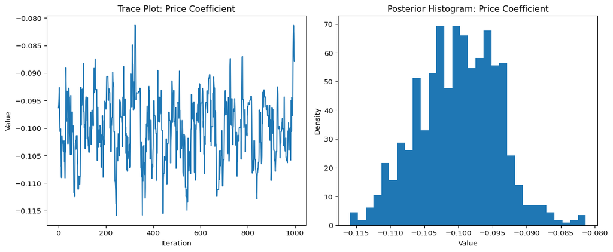

```python
plt.figure(figsize=(12, 5))

# Trace plot
plt.subplot(1, 2, 1)
plt.plot(samples[:, 3])
plt.title("Trace Plot: Price Coefficient")
plt.xlabel("Iteration")
plt.ylabel("Value")

# Histogram
plt.subplot(1, 2, 2)
plt.hist(samples[:, 3], bins=30, density=True)
plt.title("Posterior Histogram: Price Coefficient")
plt.xlabel("Value")
plt.ylabel("Density")

plt.tight_layout()
plt.show()
```

## 6 Discussion

The parameter estimates represent how much each feature affects a respondent’s utility for a product.

If we observe that 𝛽Netflix > 𝛽Prime , this implies that, all else equal, respondents preferred Netflix-branded options over Prime-branded ones.

The size of the coefficient difference indicates the strength of that preference.

Interpreting Price Sensitivity We also observe that 𝛽priceis negative, which is what we would expect in real consumer choice data. A negative price coefficient means that as price increases, utility decreases, holding other attributes constant. This aligns with economic theory — people prefer cheaper options.

The magnitude of the price coefficient tells us how sensitive respondents are to price compared to other features like brand or ad presence.